# AI/ML for Healthcare Applications : Lab 6b Word Embeddings

Based on material from the Georgetown [Health Informatics and Data Science](https://healthinformatics.georgetown.edu) program and licensed under [CC4.0](https://creativecommons.org/licenses/by/4.0/)

```python
import pandas as pd
import numpy as np
import matplotlib.pyplot as plt
from collections import Counter
```

In this workshop, we will explore how to represent textual data for Machine Learning. In this first part we will explore the **Word embeddings** representation of enconding text to vectors

We specifically explore how to load, train word embeddings using the word2vec algorithm using a popular package called **Gensim** More details about gensim can be found here: https://radimrehurek.com/gensim/models/word2vec.html

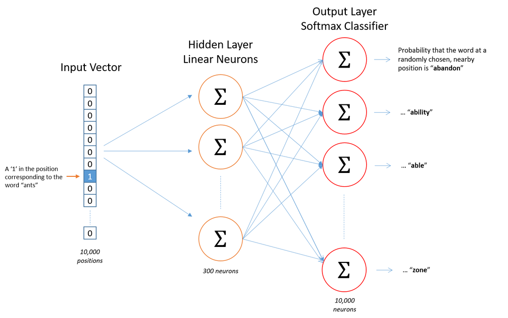

**Brief explanation**

The underlying assumption of Word2Vec is that two words sharing similar contexts also share a similar meaning and consequently a similar vector representation from the model. For instance: "dog", "puppy" and "pup" are often used in similar situations, with similar surrounding words like "good", "fluffy" or "cute", and according to Word2Vec they will therefore share a similar vector representation.

From this assumption, Word2Vec can be used to find out the relations between words in a dataset, compute the similarity between them, or use the vector representation of those words as input for other applications such as text classification or clustering.

### Training word embeddings using Gensim

We will train word vectors/embeddings on our ADR corpus

Load dataset

```python
!wget https://raw.githubusercontent.com/ICBI/AIMAHEAD_GU_publicCourseData/main/ML_Concepts/ade_corpus_subset.csv
ade_file = "/content/ade_corpus_subset.csv"
```

```
--2024-11-11 17:45:39--  https://raw.githubusercontent.com/ICBI/AIMAHEAD_GU_publicCourseData/main/ML_Concepts/ade_corpus_subset.csv
Resolving raw.githubusercontent.com (raw.githubusercontent.com)... 185.199.109.133, 185.199.111.133, 185.199.110.133, ...
Connecting to raw.githubusercontent.com (raw.githubusercontent.com)|185.199.109.133|:443... connected.
HTTP request sent, awaiting response... 200 OK
Length: 1571574 (1.5M) [text/plain]
Saving to: ‘ade_corpus_subset.csv’

ade_corpus_subset.c 100%[===================>]   1.50M  --.-KB/s    in 0.05s

2024-11-11 17:45:40 (32.2 MB/s) - ‘ade_corpus_subset.csv’ saved [1571574/1571574]
```

```python
ade_df = pd.read_csv(ade_file)
```

```python
print(ade_df.shape)
ade_df.head()
```

```
(11272, 3)
```

|  | pmid | sentence | label |
| --- | --- | --- | --- |
| 0 | 11174414 | Severe rash, including the Stevens-Johnson syn... | 1 |
| 1 | 12645965 | Significant systemic manifestations are rare. | 0 |
| 2 | 17172571 | Chronic paroxysmal hemicrania (CPH) is a rare ... | 0 |
| 3 | 16109609 | Of twenty other patients in our practice who r... | 0 |
| 4 | 15779196 | A 74-year old white man was undergoing treatme... | 0 |

Training using a toy example:

```python
from gensim.models import Word2Vec
```

Sentences should be tokenized for training

```python
sentences = [['this', 'is', 'the', 'first', 'sentence', 'for', 'word2vec'],
			['this', 'is', 'the', 'second', 'sentence'],
			['yet', 'another', 'sentence'],
			['one', 'more', 'sentence'],
			['and', 'the', 'final', 'sentence']]
```

```python
sentences
```

```
[['this', 'is', 'the', 'first', 'sentence', 'for', 'word2vec'],
 ['this', 'is', 'the', 'second', 'sentence'],
 ['yet', 'another', 'sentence'],
 ['one', 'more', 'sentence'],
 ['and', 'the', 'final', 'sentence']]
```

```python
# train model
model = Word2Vec(sentences, min_count=1)
```

Few Parameters:

- size: (default 100) The number of dimensions of the embedding, e.g. the length of the dense vector to represent each token (word).
- window: (default 5) The maximum distance between a target word and words around the target word.
- min_count: (default 5) The minimum count of words to consider when training the model; words with an occurrence less than this count will be ignored.
- workers: (default 3) The number of threads to use while training.
- sg: (default 0 or CBOW) The training algorithm, either CBOW (0) or skip gram (1).

```python
# summarize the loaded model
print(model)
```

```
Word2Vec<vocab=14, vector_size=100, alpha=0.025>
```

```python
model.wv.index_to_key
```

```
['sentence',
 'the',
 'is',
 'this',
 'final',
 'and',
 'more',
 'one',
 'another',
 'yet',
 'second',
 'word2vec',
 'for',
 'first']
```

```python
# summarize vocabulary
words = model.wv.index_to_key
```

```python
words
```

```
['sentence',
 'the',
 'is',
 'this',
 'final',
 'and',
 'more',
 'one',
 'another',
 'yet',
 'second',
 'word2vec',
 'for',
 'first']
```

```python
# access vector for one word
print(model.wv['sentence'])
```

```
[-5.3622725e-04  2.3643136e-04  5.1033497e-03  9.0092728e-03
 -9.3029495e-03 -7.1168090e-03  6.4588725e-03  8.9729885e-03
 -5.0154282e-03 -3.7633716e-03  7.3805046e-03 -1.5334714e-03
 -4.5366134e-03  6.5540518e-03 -4.8601604e-03 -1.8160177e-03
  2.8765798e-03  9.9187379e-04 -8.2852151e-03 -9.4488179e-03
  7.3117660e-03  5.0702621e-03  6.7576934e-03  7.6286553e-04
  6.3508903e-03 -3.4053659e-03 -9.4640139e-04  5.7685734e-03
 -7.5216377e-03 -3.9361035e-03 -7.5115822e-03 -9.3004224e-04
  9.5381187e-03 -7.3191668e-03 -2.3337686e-03 -1.9377411e-03
  8.0774371e-03 -5.9308959e-03  4.5162440e-05 -4.7537340e-03
 -9.6035507e-03  5.0072931e-03 -8.7595852e-03 -4.3918253e-03
 -3.5099984e-05 -2.9618145e-04 -7.6612402e-03  9.6147433e-03
  4.9820580e-03  9.2331432e-03 -8.1579173e-03  4.4957981e-03
 -4.1370760e-03  8.2453608e-04  8.4986202e-03 -4.4621765e-03
  4.5175003e-03 -6.7869602e-03 -3.5484887e-03  9.3985079e-03
 -1.5776526e-03  3.2137157e-04 -4.1406299e-03 -7.6826881e-03
 -1.5080082e-03  2.4697948e-03 -8.8802696e-04  5.5336617e-03
 -2.7429771e-03  2.2600652e-03  5.4557943e-03  8.3459532e-03
 -1.4537406e-03 -9.2081428e-03  4.3705525e-03  5.7178497e-04
  7.4419081e-03 -8.1328274e-04 -2.6384138e-03 -8.7530091e-03
 -8.5655687e-04  2.8265631e-03  5.4014288e-03  7.0526563e-03
 -5.7031214e-03  1.8588197e-03  6.0888636e-03 -4.7980510e-03
 -3.1072604e-03  6.7976294e-03  1.6314756e-03  1.8991709e-04
  3.4736372e-03  2.1777749e-04  9.6188262e-03  5.0606038e-03
 -8.9173904e-03 -7.0415605e-03  9.0145587e-04  6.3925339e-03]
```

**train it on our ADE corpus**

**Note:** We do not need the label column to train word vecctors. Word2Vec is a "unsupervised" (sort of) algorithm that learns vectors by building a fake classification task, which is to predict context words. Thus you only require a corpus of text to train your word vecctors.

```python
ade_df.head()
```

|  | pmid | sentence | label |
| --- | --- | --- | --- |
| 0 | 11174414 | Severe rash, including the Stevens-Johnson syn... | 1 |
| 1 | 12645965 | Significant systemic manifestations are rare. | 0 |
| 2 | 17172571 | Chronic paroxysmal hemicrania (CPH) is a rare ... | 0 |
| 3 | 16109609 | Of twenty other patients in our practice who r... | 0 |
| 4 | 15779196 | A 74-year old white man was undergoing treatme... | 0 |

```python
sentences = ade_df['sentence'].values.tolist()
```

```python
sentences[:5]
```

```
['Severe rash, including the Stevens-Johnson syndrome (SJS), is the major toxicity of nevirapine and is described in the package labeling with a prominent, boxed warning.',
 'Significant systemic manifestations are rare.',
 'Chronic paroxysmal hemicrania (CPH) is a rare primary headache syndrome, which is classified along with cluster headache and short-lasting unilateral neuralgiform headache attacks with conjunctival injection and tearing (SUNCT) as a trigeminal autonomic cephalalgia.',
 'Of twenty other patients in our practice who received gemcitabine for refractory lymphoma without developing pericardial effusion, none had received prior direct radiation to the heart.',
 'A 74-year old white man was undergoing treatment with palliative chemotherapy for Stage IV Prostate Adenocarcinoma with multiple osteoblastic metastases.']
```

```python
len(sentences)
```

```
11272
```

```python
sentences[1]
```

```
'Significant systemic manifestations are rare.'
```

Tokenize using nltk

```python
import nltk
from nltk.tokenize import word_tokenize
```

```python
nltk.download('punkt')
```

```
True
```

```python
tokenized_sents = [word_tokenize(sent.lower()) for sent in sentences]
```

```python
tokenized_sents[1]
```

```
['significant', 'systemic', 'manifestations', 'are', 'rare', '.']
```

```python
import multiprocessing
cores = multiprocessing.cpu_count()
```

```python
cores
```

```
2
```

```python
# train model
model = Word2Vec(tokenized_sents, vector_size = 100, workers=cores)
```

```python
# summarize the loaded model
print(model)
```

```
Word2Vec<vocab=4219, vector_size=100, alpha=0.025>
```

```python
# summarize vocabulary
words = list(model.wv.index_to_key)
```

```python
len(words)
```

```
4219
```

```python
words[:100]
```

```
['.',
 'of',
 'the',
 ',',
 'and',
 'a',
 'with',
 'in',
 'to',
 'was',
 ')',
 '(',
 'is',
 'for',
 'after',
 'patients',
 'patient',
 'case',
 'treatment',
 ':',
 'therapy',
 'this',
 'an',
 'by',
 'we',
 'report',
 'be',
 'that',
 'developed',
 'as',
 'who',
 'were',
 'on',
 'been',
 'are',
 'acute',
 'associated',
 'may',
 'treated',
 'or',
```

[output cut: 45 more lines]

```
 'presented',
 'receiving',
 'toxicity',
 'can',
 'pulmonary',
 'when',
 'days',
 'both',
 'our',
 'complication',
 'cause',
 ';',
 'hepatitis',
 'dose',
 'used']
```

```python
wv = model.wv
```

```python
wv.get_vector("intravenous")
```

```
array([-0.39875904,  0.10907988, -0.02597096,  0.42519498,  0.34925717,
       -0.41556183,  0.00913824,  0.70692575, -0.14091659, -0.5672094 ,
        0.31454393, -0.7011039 , -0.04549343,  0.00539489,  0.5085455 ,
       -0.15884991, -0.02423636, -0.16782638,  0.3111632 , -0.57709885,
        0.4465837 ,  0.16950354,  0.7808553 , -0.1572753 ,  0.05829693,
        0.03274604,  0.08637619,  0.17898503, -0.41259623, -0.1299917 ,
        0.4264103 , -0.22362909,  0.61233765, -0.05733183, -0.25138816,
        0.3686075 ,  0.05241669, -0.4523994 , -0.6631694 , -0.07176954,
        0.23356226, -0.27354795, -0.32065985,  0.3185664 ,  0.33899814,
       -0.04605159, -0.14673463, -0.00558852,  0.20276998,  0.3815505 ,
        0.25302485, -0.7255919 , -0.20296824, -0.00603165, -0.52733874,
        0.21810314,  0.11140664, -0.15143485, -0.07689863, -0.09573349,
       -0.04816917,  0.4457078 ,  0.44851238, -0.12109262, -0.7729105 ,
        0.42373562,  0.03245445,  0.7713453 , -0.561308  ,  0.35577217,
        0.18074378,  0.603814  ,  0.5019385 ,  0.136797  ,  0.72179717,
        0.04110049,  0.28567928, -0.19421725, -0.4985645 , -0.2804321 ,
       -0.5456136 , -0.32359612, -0.67312074,  0.657208  , -0.33129835,
       -0.21417563,  0.12683226, -0.00818178,  0.15532988, -0.00256895,
        0.33793196,  0.31100133, -0.17213061,  0.42449483,  0.8655523 ,
        0.62621546,  0.48276865, -0.6500923 , -0.01550849, -0.02056007],
      dtype=float32)
```

```python
wv.get_vector("intravenous").shape
```

```
(100,)
```

```python
wv.get_vector("disease")
```

```
array([ 0.30018994,  0.1501556 ,  0.13334262, -0.07705705,  0.11959952,
       -0.4891517 ,  0.10971069,  0.7613443 ,  0.25685942, -0.5090783 ,
       -0.04465331, -0.5131951 ,  0.20196399, -0.1548215 ,  0.24256898,
       -0.23830074,  0.03255041,  0.44557935,  0.73351413, -0.54015577,
        0.13411233, -0.39086342,  0.32378328,  0.04366263,  0.06785204,
       -0.15896663,  0.1287099 ,  0.15627785, -0.3938586 , -0.18016724,
        0.70466244, -0.20885603,  0.70247763, -0.47613397, -0.05117573,
        0.7858058 ,  0.400613  , -0.2891565 , -0.61334604, -0.23159555,
        0.24987401, -0.74229985, -0.34042278, -0.38612548,  0.2608923 ,
       -0.19941568, -0.41931742, -0.34045622,  0.16271083,  0.26196516,
       -0.04526762, -0.46585673, -0.4614727 ,  0.3735718 , -0.2360598 ,
        0.5032474 , -0.20794693, -0.641482  , -0.0356616 , -0.08661328,
        0.5126611 , -0.04536517,  0.3577353 ,  0.29762688, -0.64787394,
        0.70851666, -0.35672054,  0.31950393, -0.38793457,  0.29251388,
        0.5242138 ,  0.4357135 ,  0.5297749 ,  0.4452839 ,  0.6919986 ,
        0.117459  ,  0.13275173,  0.02412821,  0.06004947,  0.48584384,
       -0.4599038 , -0.40988332, -0.8016501 ,  0.5406177 , -0.39905474,
       -0.1568136 ,  0.33500922,  0.088309  ,  0.5723507 , -0.30183423,
        0.57583255,  0.01051752, -0.05497909,  0.38833764,  0.38491544,
        0.50610405,  0.16726099, -0.90174747, -0.61265767, -0.1345447 ],
      dtype=float32)
```

**Get top most similar words in vocab**

```python
wv.most_similar('intravenous')
```

```
[('interferon', 0.9897710680961609),
 ('ribavirin', 0.9883931875228882),
 ('prednisolone', 0.9859846234321594),
 ('initiating', 0.9857826828956604),
 ('ifn-alpha', 0.9850307703018188),
 ('methotrexate', 0.9849671125411987),
 ('alpha', 0.9840911030769348),
 ('infusion', 0.9831039309501648),
 ('oral', 0.9824706315994263),
 ('15', 0.9817301630973816)]
```

```python
wv.most_similar('fever')
```

```
[('diabetes', 0.9898825883865356),
 ('erythema', 0.9889020323753357),
 ('dyspnea', 0.988660991191864),
 ('died', 0.9885514974594116),
 ('rash', 0.9877966642379761),
 ('eosinophilia', 0.9864538311958313),
 ('nausea', 0.9854678511619568),
 ('shortly', 0.9851245880126953),
 ('mellitus', 0.9851023554801941),
 ('proteinuria', 0.9848697185516357)]
```

Most dissimilar

```python
wv.most_similar(negative='fever')
```

```
[('be', -0.29131630063056946),
 ('have', -0.32389363646507263),
 ('this', -0.36663350462913513),
 ('has', -0.3707963526248932),
 ('aim', -0.3714863061904907),
 ('may', -0.3727034330368042),
 ('is', -0.37932851910591125),
 ('it', -0.39902177453041077),
 ('that', -0.4014112949371338),
 ('conclude', -0.4097268283367157)]
```

**Similarity score**

```python
wv.similarity('fever', 'infection')
```

```
0.95837253
```

```python
wv.similarity('fever', 'that')
```

[output not shown]

**Odd one out**

```python
wv.doesnt_match(["fever", "infection", "oral", "rash"])
```

```
'oral'
```

**Analogies**

man-> king : woman:??

```python
result = wv.most_similar(positive=['cancer', 'infection'], negative=['fever'])
print("{}: {:.4f}".format(*result[0]))
```

```
acquired: 0.9602
```

```python
result
```

```
[('acquired', 0.9602131247520447),
 ('elderly', 0.9595950841903687),
 ('pregnant', 0.9595454335212708),
 ('scleroderma', 0.9589462280273438),
 ('metastatic', 0.9563495516777039),
 ('angina', 0.9557268023490906),
 ('suffering', 0.9549254775047302),
 ('adult', 0.9546331167221069),
 ('young', 0.9541780352592468),
 ('breast', 0.9535177946090698)]
```

```python
def analogy(x1, x2, y1):
    result = wv.most_similar(positive=[y1, x2], negative=[x1])
    print(result)
```

```python
analogy("infection", "fever", "diabetes")
```

```
[('later', 0.9729655981063843), ('died', 0.9729381799697876), ('mellitus', 0.9713751077651978), ('month', 0.9713124632835388), ('cell', 0.9698188304901123), ('while', 0.9643771052360535), ('discharge', 0.961397111415863), ('cyanamide', 0.959126889705658), ('discharged', 0.9582447409629822), ('subseq…
```

This is a very small set. and hence the results are not very good for analogies. Typically word embeddings usinf word2vec are trained on millions on documents

### Loading a pre-trained word embeddings trained on a very large corpus

Glove6B is trained on wikipedia and news articles with 6B tokens, 400lk vocab

I will use the 100d vectors below as a mix between speed and smallness vs. quality. If you try out the 50d vectors, they basically work for similarity but clearly aren't as good for analogy problems. If you load the 300d vectors, they're even better than the 100d vectors.

```python
plt.style.use('ggplot')

from sklearn.decomposition import PCA

from gensim.test.utils import datapath, get_tmpfile
from gensim.models import KeyedVectors
from gensim.scripts.glove2word2vec import glove2word2vec
```

```python
! wget https://proteininformationresource.org/miscellaneous/student/glove.6B.100d.txt
```

```
--2024-11-11 17:46:12--  https://proteininformationresource.org/miscellaneous/student/glove.6B.100d.txt
Resolving proteininformationresource.org (proteininformationresource.org)... 128.175.240.205
Connecting to proteininformationresource.org (proteininformationresource.org)|128.175.240.205|:443... connected.
HTTP request sent, awaiting response... 200 OK
Length: 347116733 (331M) [text/plain]
Saving to: ‘glove.6B.100d.txt’

glove.6B.100d.txt   100%[===================>] 331.04M  42.3MB/s    in 8.3s

2024-11-11 17:46:20 (39.9 MB/s) - ‘glove.6B.100d.txt’ saved [347116733/347116733]
```

```python
glove_file = "/content/glove.6B.100d.txt"
```

```python
word2vec_glove_file = get_tmpfile("glove.6B.100d.word2vec.txt")
glove2word2vec(glove_file, word2vec_glove_file)
```

```
(400000, 100)
```

```python
wv = KeyedVectors.load_word2vec_format(word2vec_glove_file)
```

```python
wv.get_vector("obama").shape
```

```
(100,)
```

```python
wv.get_vector("obama")
```

```
array([-0.44413  ,  0.59188  ,  0.98472  , -0.058361 ,  0.6077   ,
       -0.68421  ,  0.019399 ,  0.099464 , -0.13403  ,  0.24832  ,
       -0.24049  , -0.35876  , -0.29002  , -0.39814  ,  0.02137  ,
       -0.25071  , -0.013359 , -0.044295 , -0.29525  , -0.64601  ,
        0.29299  , -0.37601  , -0.3124   , -0.1293   , -0.93938  ,
        0.20459  , -0.72762  ,  0.2271   ,  0.44782  , -0.48476  ,
        0.7424   ,  1.1035   ,  0.6844   ,  0.86386  , -0.22639  ,
        0.68557  , -0.64844  , -0.48585  , -0.18262  ,  1.3293   ,
       -1.4314   , -0.95057  ,  0.94967  ,  0.55113  , -0.84357  ,
       -0.73851  , -0.13937  , -0.0097541, -0.28226  , -0.89138  ,
        0.15243  , -0.2845   ,  0.84001  ,  1.0873   , -0.016641 ,
       -2.5264   ,  0.50699  , -0.52419  ,  0.40204  ,  0.14475  ,
       -0.51315  ,  0.097834 ,  0.47384  , -0.67161  ,  0.52199  ,
        0.50871  ,  0.29222  ,  0.90184  , -0.2625   , -0.097745 ,
        0.21947  ,  0.12971  , -0.96543  , -0.20776  ,  0.0093728,
        0.36457  ,  0.040391 ,  0.09403  , -0.65371  , -0.37233  ,
        0.52824  , -0.61497  ,  0.0082911, -0.56275  , -1.14     ,
       -0.84073  , -0.15861  ,  0.3298   , -0.2238   , -1.2831   ,
        0.0093602, -0.033262 ,  0.20877  ,  0.093094 , -0.79095  ,
       -0.57303  ,  0.060038 ,  0.2637   ,  0.39312  ,  0.58784  ],
      dtype=float32)
```

```python
wv.most_similar('obama')
```

```
[('barack', 0.937216579914093),
 ('bush', 0.927285373210907),
 ('clinton', 0.896000325679779),
 ('mccain', 0.8875633478164673),
 ('gore', 0.8000321388244629),
 ('hillary', 0.7933662533760071),
 ('dole', 0.7851964831352234),
 ('rodham', 0.7518897652626038),
 ('romney', 0.7488929629325867),
 ('kerry', 0.7472624182701111)]
```

Coming back to analogies `man-> king : woman:??`

```python
result = wv.most_similar(positive=['woman', 'king'], negative=['man'])
print("{}: {:.4f}".format(*result[0]))
```

```
queen: 0.7699
```

```python
def analogy(x1, x2, y1):
    result = wv.most_similar(positive=[y1, x2], negative=[x1])
    #return result[0][0]
    return result
```

```python
analogy('japan', 'japanese', 'australia')
```

```
[('australian', 0.8923497796058655),
 ('zealand', 0.8012940883636475),
 ('british', 0.7840811610221863),
 ('australians', 0.6766527891159058),
 ('indian', 0.670796811580658),
 ('canadian', 0.6601305603981018),
 ('english', 0.6396120190620422),
 ('england', 0.6350405812263489),
 ('sydney', 0.6257352232933044),
 ('britain', 0.6175569295883179)]
```

```python
analogy('australia', 'beer', 'france')
```

```
[('champagne', 0.6480063796043396),
 ('wine', 0.6029773354530334),
 ('cognac', 0.599911093711853),
 ('drink', 0.596866250038147),
 ('perfume', 0.5843736529350281),
 ('drinks', 0.5787434577941895),
 ('vodka', 0.5771391987800598),
 ('beers', 0.563433051109314),
 ('anheuser', 0.5613827705383301),
 ('bourbon', 0.552852988243103)]
```

```python
analogy('tall', 'tallest', 'long')
```

```
[('longest', 0.7037105560302734),
 ('the', 0.6229448914527893),
 ('major', 0.6216300129890442),
 ('time', 0.6173370480537415),
 ('first', 0.616451621055603),
 ('since', 0.60569828748703),
 ('decade', 0.6019695997238159),
 ('busiest', 0.6005878448486328),
 ('its', 0.6004385352134705),
 ('part', 0.60023432970047)]
```

```python
analogy('good', 'fantastic', 'bad')
```

```
[('terrible', 0.7074226140975952),
 ('awful', 0.70609450340271),
 ('horrible', 0.6906466484069824),
 ('scary', 0.6802915334701538),
 ('weird', 0.6775556206703186),
 ('crazy', 0.6615544557571411),
 ('strange', 0.6522735953330994),
 ('dreadful', 0.6404813528060913),
 ('bizarre', 0.6389496326446533),
 ('incredible', 0.6321425437927246)]
```

```python
print(wv.doesnt_match("breakfast cereal dinner lunch".split()))
```

```
cereal
```

## Visualization of embeddings

```python
def display_pca_scatterplot(model, words=None, sample=0):
    if words == None:
        if sample > 0:
            words = np.random.choice(list(model.vocab.keys()), sample)
        else:
            words = [ word for word in model.vocab ]

    word_vectors = np.array([model[w] for w in words])

    twodim = PCA().fit_transform(word_vectors)[:,:2]

    plt.figure(figsize=(16,16))
    plt.scatter(twodim[:,0], twodim[:,1], edgecolors='k', c='r')
    for word, (x,y) in zip(words, twodim):
        plt.text(x+0.05, y+0.05, word)
    plt.show()
```

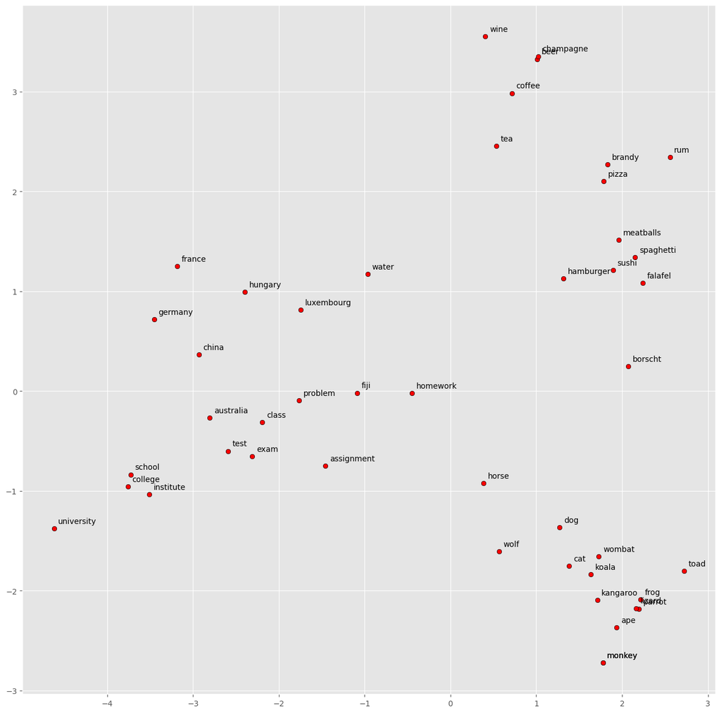

```python
display_pca_scatterplot(wv,
                        ['coffee', 'tea', 'beer', 'wine', 'brandy', 'rum', 'champagne', 'water',
                         'spaghetti', 'borscht', 'hamburger', 'pizza', 'falafel', 'sushi', 'meatballs',
                         'dog', 'horse', 'cat', 'monkey', 'parrot', 'koala', 'lizard',
                         'frog', 'toad', 'monkey', 'ape', 'kangaroo', 'wombat', 'wolf',
                         'france', 'germany', 'hungary', 'luxembourg', 'australia', 'fiji', 'china',
                         'homework', 'assignment', 'problem', 'exam', 'test', 'class',
                         'school', 'college', 'university', 'institute'])
```

```python
wv.most_similar('nuclear')
```

```
[('atomic', 0.8345614075660706),
 ('weapons', 0.7992491126060486),
 ('missile', 0.7333793640136719),
 ('reactor', 0.727847158908844),
 ('iran', 0.7257774472236633),
 ('enrichment', 0.7181844711303711),
 ('proliferation', 0.7147133350372314),
 ('uranium', 0.7099131345748901),
 ('reactors', 0.7078331708908081),
 ('korea', 0.6898523569107056)]
```

## Vectors trained on millions of PubMed abstracts

Interested in pre-trained word embeddings for biomedical and clinical documents:

https://github.com/ncbi-nlp/BioSentVec

```python
! wget https://proteininformationresource.org/miscellaneous/student/PubMed-w2v.bin
```

```
--2024-11-11 17:47:55--  https://proteininformationresource.org/miscellaneous/student/PubMed-w2v.bin
Resolving proteininformationresource.org (proteininformationresource.org)... 128.175.240.205
Connecting to proteininformationresource.org (proteininformationresource.org)|128.175.240.205|:443... connected.
HTTP request sent, awaiting response... 200 OK
Length: 1909156308 (1.8G) [application/octet-stream]
Saving to: ‘PubMed-w2v.bin’

PubMed-w2v.bin      100%[===================>]   1.78G  42.3MB/s    in 44s

2024-11-11 17:48:39 (41.5 MB/s) - ‘PubMed-w2v.bin’ saved [1909156308/1909156308]
```

```python
data_dir = "/content/"
w2c_bin_file = data_dir + "PubMed-w2v.bin"
```

```python
pubmed_wv = KeyedVectors.load_word2vec_format(datapath(w2c_bin_file), binary=True)
```

```python
pubmed_wv.vector_size
```

```
200
```

```python
pubmed_wv.get_vector("cancer")
```

```
array([-0.22176959,  0.34126785, -0.5282118 , -0.08535862, -0.35832503,
       -0.35342082, -0.28617635, -0.1701573 ,  0.24315356,  0.04052326,
        0.29832423,  0.04738654,  0.14181876,  0.14213969,  0.09183084,
       -0.12004669, -0.49956045,  0.0196952 ,  0.24415348,  0.15610503,
        0.22340877,  0.17664158,  0.40977743, -0.1028608 ,  0.02051529,
       -0.18442406,  0.40036437,  0.0048343 , -0.08292153,  0.14889263,
       -0.49798098,  0.28300712, -0.19450186,  0.15942919,  0.26144913,
        0.24753122, -0.12070846,  0.25870386,  0.23568675, -0.16480508,
       -0.01290027, -0.03193538,  0.17710465,  0.13833651, -0.34391066,
        0.05684075, -0.1469353 , -0.21669032, -0.05528568, -0.2921147 ,
       -0.10552497, -0.09118081,  0.04759439, -0.20183203,  0.2260163 ,
       -0.04044775,  0.0175029 ,  0.2814055 ,  0.09478283,  0.06810474,
        0.11599492,  0.24131818,  0.09850662,  0.10702335,  0.23743771,
        0.00643789, -0.03860342, -0.24346724,  0.09210841,  0.44862723,
        0.48499304, -0.15052329, -0.01192939, -0.4018667 , -0.33769938,
       -0.052072  , -0.12986965, -0.12132445,  0.0923662 ,  0.10681771,
        0.10484588, -0.29449397, -0.01264069,  0.00100716,  0.05910284,
       -0.08573925,  0.4234557 ,  0.31635928,  0.26049933, -0.15934017,
       -0.47736102,  0.24607988,  0.04527711, -0.22218336,  0.38110206,
       -0.12315795,  0.19231564,  0.24875611, -0.50221354,  0.34605157,
       -0.30046007, -0.02357207, -0.00970767,  0.29215425, -0.12321068,
        0.3055299 , -0.07696908, -0.00310187, -0.30995014, -0.03161974,
        0.07574332,  0.00589919,  0.19368577,  0.16475324, -0.01994421,
        0.04152327,  0.14226283,  0.1444007 , -0.08178647,  0.18467228,
        0.17770468, -0.10991531,  0.01892428, -0.5178991 , -0.4838631 ,
       -0.01002163, -0.20149283,  0.12593228,  0.01593531, -0.03646014,
        0.30827734,  0.13449512, -0.29535124,  0.19816035,  0.08686126,
       -0.03208366,  0.42864347,  0.09140225,  0.1786332 , -0.10889318,
       -0.03092424,  0.02157032,  0.51194304,  0.12640437,  0.38791505,
        0.16703482,  0.09444859,  0.22153741,  0.09586744, -0.10875621,
       -0.05391807, -0.22565247,  0.5055096 , -0.04892442,  0.30454955,
       -0.20789245, -0.11538031, -0.01896546,  0.2833553 ,  0.20623551,
        0.04416776,  0.19099829, -0.43789995,  0.16406122, -0.04136417,
       -0.18019529,  0.04501045, -0.02609527, -0.19764693, -0.19608976,
       -0.0013516 ,  0.266648  , -0.05266457, -0.2706915 ,  0.14660646,
        0.2463516 , -0.06747112, -0.01008276,  0.02694788, -0.13191985,
       -0.0349759 ,  0.11901467, -0.24457271,  0.21741636, -0.07413535,
        0.1124128 , -0.10006971, -0.1603236 , -0.07967499,  0.00855414,
        0.05417852, -0.13888238,  0.00534228,  0.34418127, -0.10884557,
       -0.296408  ,  0.08779597,  0.3996494 ,  0.17172185, -0.39902547],
      dtype=float32)
```

```python
model = pubmed_wv
```

```python
model.most_similar('nuclear')
```

```
[('Nuclear', 0.814135730266571),
 ('CRM-1-mediated', 0.683521568775177),
 ('factor-E2', 0.6823976039886475),
 ('factor-kappaB1', 0.680070161819458),
 ('transportin-dependent', 0.679000973701477),
 ('non-nuclear', 0.670287013053894),
 ('factor-(kappa)B', 0.6654255986213684),
 ('CRM-1-dependent', 0.6646666526794434),
 ('nucleoplasmic', 0.6644253134727478),
 ('envelope/endoplasmic', 0.6548577547073364)]
```

```python
model.most_similar('Nuclear')
```

```
[('nuclear', 0.8141359090805054),
 ('-nuclear', 0.628040611743927),
 ('Cadmium-113', 0.6122799515724182),
 ('Factor-kappaB', 0.593903660774231),
 ('(sup13)C', 0.5834121108055115),
 ('Fluorine-19', 0.5741490721702576),
 ('factor-erythroid-2-related', 0.5697154402732849),
 ('Factor-kappa', 0.5682513117790222),
 ('factor-kappaBeta', 0.5667451620101929),
 ('runon', 0.5602378845214844)]
```

```python
model.most_similar('cancer')
```

```
[('cancers', 0.8273031115531921),
 ('caner', 0.7624797821044922),
 ('BCa', 0.7224228978157043),
 ('PCa', 0.7091118097305298),
 ('can-cer', 0.7075604200363159),
 ('CRC', 0.7060142755508423),
 ('BRCA1/2-associated', 0.7047150135040283),
 ('breast-cancer', 0.7009023427963257),
 ('adenocarcinoma', 0.6939370036125183),
 ('castrate-refractory', 0.6888855695724487)]
```

```python
model.most_similar('CD19+')
```

```
[('CD20+', 0.9026835560798645),
 ('CD38+', 0.8998805284500122),
 ('CD5+', 0.8862646222114563),
 ('HLA-DR+', 0.8825798034667969),
 ('CD2+', 0.8808907270431519),
 ('CD21+', 0.8722430467605591),
 ('CD23+', 0.8706403374671936),
 ('CD3+', 0.8636170029640198),
 ('CD19(+)', 0.8604583740234375),
 ('CD5-', 0.8590682744979858)]
```

```python
model.most_similar('apoptosis')
```

```
[('apoptotic', 0.7831601500511169),
 ('Fas-triggered', 0.7798079252243042),
 ('caspase-3-dependent', 0.7775819897651672),
 ('staurosporine-mediated', 0.7771020531654358),
 ('apotosis', 0.7765617370605469),
 ('2-methoxyestradiol-induced', 0.7758632302284241),
 ('caspase-3-independent', 0.7693705558776855),
 ('death-receptor-mediated', 0.768819272518158),
 ('NCTD-induced', 0.768020510673523),
 ('apoptosis/necrosis', 0.7644252181053162)]
```

```python
model.most_similar('methylation')
```

```
[('Methylation', 0.8316795229911804),
 ('hypomethylation', 0.8111790418624878),
 ('hypermethylation', 0.795872688293457),
 ('methylations', 0.7453095316886902),
 ('demethylation', 0.7362307906150818),
 ('GTF2A1L', 0.7296731472015381),
 ('H3K79', 0.7276176810264587),
 ('methylated', 0.7239834666252136),
 ('promoter-associated', 0.7215445041656494),
 ('H3-Lys9', 0.7200178503990173)]
```

```python
model.most_similar(negative='cancer')
```

```
[('Microtubes', 0.29382678866386414),
 ('pMEL34', 0.2723343074321747),
 ('smallest-sized', 0.2718348801136017),
 ('Cd-HA', 0.27054348587989807),
 ('CaMV-encoded', 0.26956018805503845),
 ('NetPS', 0.2692641615867615),
 ('normoxia-normocapnia', 0.2675582766532898),
 ('methyl-alpha-galactoside', 0.26719531416893005),
 ('[(3)H]DFP', 0.26646411418914795),
 ('250-325', 0.26600533723831177)]
```

```python
def analogy(x1, x2, y1):
    result = model.most_similar(positive=[y1, x2], negative=[x1])
    print(result)
    #return result[0][0]
```

```python
analogy('flu', 'nausea', 'fever')
```

```
[('vomiting', 0.7281452417373657), ('chills', 0.7151417136192322), ('pyrexia', 0.7131693959236145), ('myalgias', 0.7110492587089539), ('nausea/vomiting', 0.7081676125526428), ('asthenia', 0.7018193006515503), ('lethargy', 0.6915605664253235), ('myalgia', 0.691351056098938), ('malaise', 0.69079977273…
```

```python
analogy('CD19+', 'B-Cell', 'Monocyte')
```

```
[('protein-1', 0.5393214225769043), ('Protein-1', 0.5160154104232788), ('monocyte', 0.49229690432548523), ('protein-1-induced', 0.4899490177631378), ('/CCL2', 0.4786629378795624), ('CCL2/monocyte', 0.46485432982444763), ('Macrophage', 0.464631587266922), ('Cartilage-derived', 0.44629839062690735), (…
```

```python
analogy('apoptosis', 'cellular', 'cancer')
```

```
[('cancers', 0.5318616032600403), ('operable', 0.4289557933807373), ('endocrine-dependent', 0.4275875985622406), ('locally', 0.42386487126350403), ('early-stage', 0.42365118861198425), ('triple-negative/basal-like', 0.42281049489974976), ('biological', 0.4209339916706085), ('cancer(CRC)', 0.42087492…
```

Done!

**Check out:**

https://projector.tensorflow.org/

**The END**  
**Authors: Dr. Samir Gupta, Dr. Matthew McCoy & ICBI AIM-AHEAD Team**